# Presentation

## EDA

This notebook contains:

- dataset processing and clean up
- minimal EDA (i.e. image size and types)

Due to some reason the downloaded dataset included duplicate versions of all the image files which need to be removed.

```
Dataset URL: https://www.kaggle.com/datasets/maysee/mushrooms-classification-common-genuss-images
License(s): copyright-authors
Downloading mushrooms-classification-common-genuss-images.zip to /workspace/ppuodz-DL.1.5/Notebooks
```

|  | Class | Duplicate Count | Total Images | Proportion |
| --- | --- | --- | --- | --- |
| 0 | Agaricus | 355 | 706 | 0.502833 |
| 1 | Amanita | 752 | 1500 | 0.501333 |
| 2 | Boletus | 1075 | 2146 | 0.500932 |
| 3 | Cortinarius | 838 | 1672 | 0.501196 |
| 4 | Entoloma | 364 | 728 | 0.500000 |
| 5 | Hygrocybe | 317 | 632 | 0.501582 |
| 6 | Lactarius | 1626 | 3126 | 0.520154 |
| 7 | Russula | 1151 | 2294 | 0.501744 |
| 8 | Suillus | 311 | 622 | 0.500000 |
| 9 | Total | 6789 | 13426 | 0.505661 |

There are some corrupt and unreadable images in the dataset that also need to be removed:

```
Removing corrupt image: dataset_temp/Mushrooms/Mushrooms/Russula/092_43B354vYxm8.jpg due to image file is truncated (92 bytes not processed)
Removing corrupt image: dataset_temp/Mushrooms/mushrooms/Mushrooms/Russula/092_43B354vYxm8.jpg due to image file is truncated (92 bytes not processed)
```

```
[PosixPath('dataset_temp/Mushrooms/Mushrooms/Russula/092_43B354vYxm8.jpg'),
 PosixPath('dataset_temp/Mushrooms/mushrooms/Mushrooms/Russula/092_43B354vYxm8.jpg')]
```

[output not shown]

|  | Count |
| --- | --- |
| (800, 600) | 1428 |
| (800, 533) | 447 |
| (800, 536) | 228 |
| (800, 531) | 198 |
| (800, 532) | 98 |
| ... | ... |
| (680, 456) | 1 |
| (732, 600) | 1 |
| (938, 624) | 1 |
| (500, 344) | 1 |
| (730, 540) | 1 |

1330 rows × 1 columns

|  | Count |
| --- | --- |
| JPEG | 6637 |

The dataset was split into test and training samples roughly trying to maintain an around 15% test sample size:

```
File count per category before split:
Mushrooms: 6637
Data split into dataset/train and dataset/test
```

```
Verification Passed: No overlapping files between train and test sets.
```

|  | Training Samples | Training Proportion (%) | Testing Samples | Testing Proportion (%) | Total Training Samples | Total Testing Samples |
| --- | --- | --- | --- | --- | --- | --- |
| Boletus | 913 | 85.25% | 158 | 14.75% | 5641 | 996 |
| Amanita | 640 | 85.56% | 108 | 14.44% | 5641 | 996 |
| Cortinarius | 715 | 85.73% | 119 | 14.27% | 5641 | 996 |
| Lactarius | 1278 | 85.20% | 222 | 14.80% | 5641 | 996 |
| Hygrocybe | 271 | 86.03% | 44 | 13.97% | 5641 | 996 |
| Entoloma | 298 | 81.87% | 66 | 18.13% | 5641 | 996 |
| Agaricus | 310 | 88.32% | 41 | 11.68% | 5641 | 996 |
| Russula | 955 | 83.55% | 188 | 16.45% | 5641 | 996 |
| Suillus | 261 | 83.92% | 50 | 16.08% | 5641 | 996 |

```
1
```

### Fine Tuning a ResNet Model for Image Classification

Our goal is to train a classification model capable of identifying different kinds of mushrooms using a pretrained ResNet model. This transfer learning approach is effective with limited data, leveraging the knowledge embedded in ResNet50 which was trained on much larger datasets.

- The model is trained with around 5000 images, applying conservative augmentation techniques.
- Initially, the model is tuned with its initial convolutional layers frozen. These layers capture universal visual features like edges, textures, and basic shapes, with filters trained to detect low-level, general characteristics useful across various visual tasks. Freezing these layers prevents their weights from updating, allowing the model to learn class-specific features without altering the general image representations already learned by ResNet50 (this minimizes overfitting) .e.g with ResNet50:
- Initially, the model's initial convolutional layers are frozen to maintain their ability to capture universal visual features such as edges and textures and basic shapes. Freezing prevents updates to these layers' weights, restricting the "learning" to clss class-specific features without altering the general image representations learned by ResNet50 therefore minimizing the risk overfitting. .e.g. structure of ResNet50:
  - An input layer processing images,
  - A 7x7 convolutional layer with 64 filters and a 3x3 max pooling layer, which together extract basic visual features like edges and textures.
  - sequence of residual blocks:
    - Conv Block 1: Three layers with 64, 64, 256 filters, repeated three times.
    - Conv Block 2: Increases filters to 128, 128, 512, repeated four times.
    - Conv Block 3: Escalates to 256, 256, 1024, with six repetitions.
    - Conv Block 4: Peaks at 512, 512, 2048 filters, repeated three times.
    - Average pooling Llyer: Reduces feature dimensionality.
    - Fully connected layer: Executes final classification.

Conv Block 4 and the Fully Connected Layer are unfrozen during training to allow fine-tuning to dataset-specific features.

- Subsequently, the entire model is unfrozen for more comprehensive fine-tuning, including the pre-trained weights, over N epochs (using an early stopping callback to stop training after the validation loss stops decreasing).

Backpropagation updates weights based on loss gradients, supplemented by learning rate adjustments such as annealing to refine updates without significant deviations from the pretrained configuration.

These layers adapt their filters to better represent the unique features of our mushroom dataset (this would in theory involve more complex feature interactions than those in the original training dataset, like ImageNet)

##### Model Selection

`ResNet18` - 18 layers deep with fewer filters and layers compared to ResNet34 and ResNet50. Specifically, it has 2 layers each in the first three sets of its convolutional blocks and 2 layers in the last set. ~11.7 million parameters.

**Achieved up to F1= ~0.91 on the validation set**

--

`ResNet34` - 34 total, it has 3, 4, 6, and 3 layers in the four sets of its convolutional. ~ 21.8 million params

**up to F1= ~0.92**

--

`ResNet50` - introduces bottleneck layers to reduce the computational burden. It has a different block structure with 1x1, 3x3, and 1x1 convolutions where the 1x1 layers are responsible for reducing and then increasing (restoring) dimensions, keeping the 3x3 layer a bottleneck with fewer input/output dimensions. ~25.6 million params.

**up to F1 = ~0.95**

#### Parameter Selection and Tuning

- `pct_start` defines the percentage of cycles for increasing the learning rate, impacting speed and effectiveness of neural network training adjustments.
- `augmentations` (i.e. image transformation like changing the scale, size, rotation of the image, using various other techniques like erasing parts of the image etc.). One issue with our results is that we tuned our model using discrete sets of transformations instead of tuning individual parameters.

Additionally:

- We've found that using class weighted to handle the imbalance in the dataset had no or limited effects so we're not employing any over or under sample technique (generating additional synthetic classes might be an option that could be explored).
- Tuning was only performed for the `ResNet50` model

##### Model fine tuning and training

We've selected `ResNet50` as our final "production" model because we were able to achieve signficantly better performance with it, however depending on the application and technical constraints this might not be the optimal choice:

- Tuning/training in a reasonable amount of time requires a relatively recent GPU with at least 16 GB or so of memory.
- However, relatively to more modern deeply learning models (especially LLMs etc.) memory requirements for inference are low and shouldn't exceed a few hundred MB even for ResNet50 for a single image and 50-100ms or so even on CPUs.
- This becomes a much more important issue when if we're working with live recognition/videos/AR rather than individual static images. In that case the 3-5x performance difference might become very significant when running on non high-end desktop/server level hardware e.g. AR and similar apps on mobile devices would generally use ResNet18, ResNet34 or more likely shallower models like MobileNet, EfficientNet etc which would have lower parameter count and be faster.

```
Augmentation Mode: mult_1.0_more_trans | Data Type: Train
using RESNET50
<function resnet50 at 0x72a4b06552d0>
```

```
Model is on CUDA
```

| epoch | train_loss | valid_loss | accuracy | f1_score | f1_score | f1_score | time |
| --- | --- | --- | --- | --- | --- | --- | --- |
| 0 | 2.125535 | 1.374057 | 0.642730 | 0.637592 | 0.642730 | 0.599818 | 00:18 |
| 1 | 1.649845 | 1.240393 | 0.685284 | 0.681334 | 0.685284 | 0.650274 | 00:18 |
| 2 | 1.393574 | 1.106691 | 0.750000 | 0.749028 | 0.750000 | 0.721309 | 00:18 |
| 3 | 1.237277 | 1.071923 | 0.750886 | 0.749900 | 0.750887 | 0.726275 | 00:18 |
| 4 | 1.175244 | 1.070255 | 0.759752 | 0.758528 | 0.759752 | 0.731426 | 00:18 |
| 5 | 1.121253 | 1.053128 | 0.761525 | 0.762907 | 0.761525 | 0.734158 | 00:18 |

| epoch | train_loss | valid_loss | accuracy | f1_score | f1_score | f1_score | time |
| --- | --- | --- | --- | --- | --- | --- | --- |
| 0 | 1.052397 | 0.881011 | 0.852837 | 0.852717 | 0.852837 | 0.837131 | 00:20 |
| 1 | 0.883487 | 0.814958 | 0.886525 | 0.886541 | 0.886525 | 0.867125 | 00:21 |
| 2 | 0.773583 | 0.764957 | 0.887411 | 0.887750 | 0.887411 | 0.873777 | 00:20 |
| 3 | 0.722277 | 0.746127 | 0.909574 | 0.908615 | 0.909574 | 0.885384 | 00:20 |
| 4 | 0.693082 | 0.751905 | 0.903369 | 0.904222 | 0.903369 | 0.888004 | 00:20 |
| 5 | 0.654971 | 0.708613 | 0.924645 | 0.924060 | 0.924645 | 0.903395 | 00:20 |
| 6 | 0.650622 | 0.735097 | 0.908688 | 0.908401 | 0.908688 | 0.883380 | 00:20 |
| 7 | 0.627631 | 0.728841 | 0.909574 | 0.909219 | 0.909574 | 0.893683 | 00:20 |
| 8 | 0.622910 | 0.702075 | 0.921099 | 0.920296 | 0.921099 | 0.898915 | 00:20 |
| 9 | 0.611950 | 0.740518 | 0.906028 | 0.906169 | 0.906028 | 0.892158 | 00:20 |
| 10 | 0.606063 | 0.717261 | 0.914007 | 0.914793 | 0.914007 | 0.901629 | 00:20 |
| 11 | 0.608423 | 0.699227 | 0.926418 | 0.926000 | 0.926418 | 0.902784 | 00:20 |
| 12 | 0.600792 | 0.696202 | 0.920213 | 0.920099 | 0.920213 | 0.901965 | 00:20 |
| 13 | 0.594399 | 0.675720 | 0.926418 | 0.926714 | 0.926418 | 0.914615 | 00:20 |
| 14 | 0.577728 | 0.671338 | 0.933511 | 0.933633 | 0.933511 | 0.926231 | 00:20 |
| 15 | 0.573266 | 0.672264 | 0.931738 | 0.931694 | 0.931738 | 0.917555 | 00:20 |
| 16 | 0.557927 | 0.666725 | 0.918440 | 0.918576 | 0.918440 | 0.900714 | 00:20 |
| 17 | 0.546183 | 0.646924 | 0.933511 | 0.933330 | 0.933511 | 0.917813 | 00:20 |
| 18 | 0.538617 | 0.639184 | 0.942376 | 0.942288 | 0.942376 | 0.929076 | 00:20 |
| 19 | 0.530187 | 0.631721 | 0.947695 | 0.947624 | 0.947695 | 0.935025 | 00:20 |
| 20 | 0.523370 | 0.623886 | 0.945035 | 0.944957 | 0.945035 | 0.927301 | 00:20 |
| 21 | 0.520889 | 0.625749 | 0.941489 | 0.941472 | 0.941489 | 0.928427 | 00:20 |
| 22 | 0.517606 | 0.624579 | 0.945922 | 0.946194 | 0.945922 | 0.931108 | 00:20 |
| 23 | 0.520089 | 0.626019 | 0.945922 | 0.946269 | 0.945922 | 0.931763 | 00:20 |
| 24 | 0.523582 | 0.623881 | 0.945922 | 0.946332 | 0.945922 | 0.932546 | 00:20 |

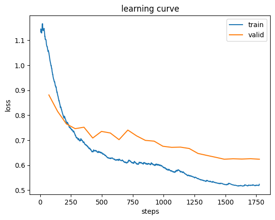

The table below show the classification metrics on full training, validation and testing samples with any augmentations turned off.

We are using a separate test sample because the validation sample was using during hyperparameter tuning and the selected parameters and augmentation options might be indirectly "overfitted" on the validation sample. However, considering that the dataset is relatively small using just 2 samples might be sufficient (ideally we'd also use CV).

```
Augmentation Mode: None | Data Type: Train
No augmentations applied.
```

|  | Dataset | N | Loss | Accuracy | Weighted F1 | Micro F1 | Macro F1 |
| --- | --- | --- | --- | --- | --- | --- | --- |
| 0 | Train | 4513 | 0.494421 | 1.000000 | 1.000000 | 1.000000 | 1.000000 |
| 1 | Validation | 1128 | 0.623874 | 0.945922 | 0.946332 | 0.945922 | 0.932546 |
| 2 | Test | 996 | 0.647552 | 0.938755 | 0.938789 | 0.938755 | 0.929871 |

#### By Class Performance

```
Augmentation Mode: mult_1.0_more_trans | Data Type: Test
No augmentations applied.
```

[output not shown]

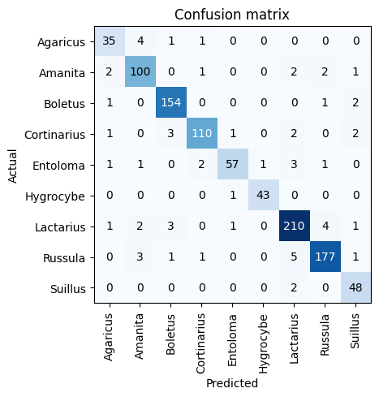

#### Largest Losses (i.e. worst predictions)

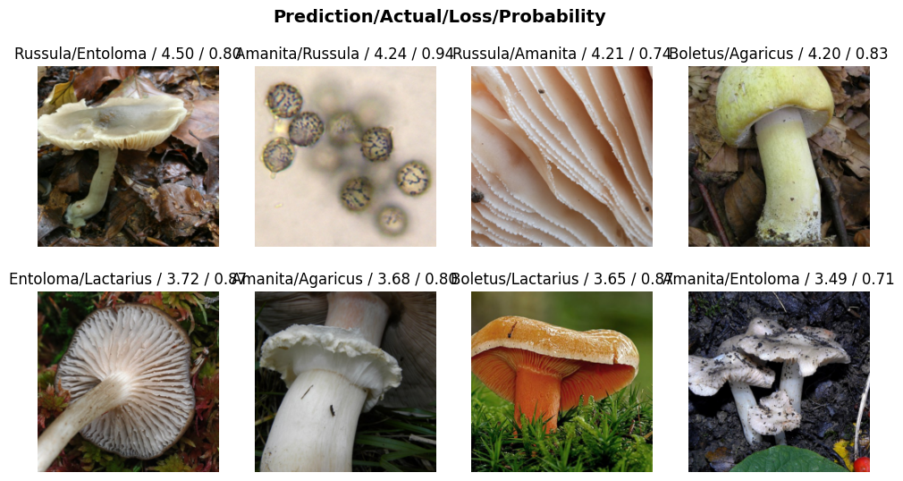

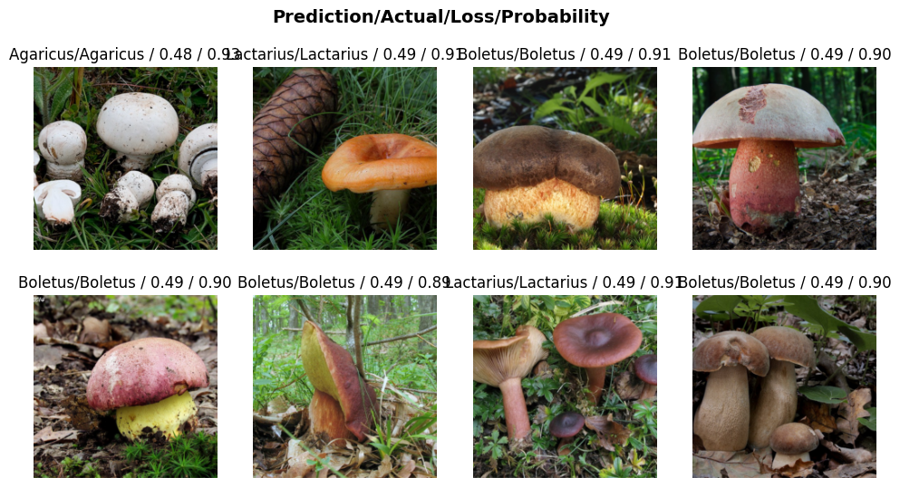

##### Most Confused Mushroom Types (actual, predicted, n. occurrences)

[output not shown]

#### Feature Analysis

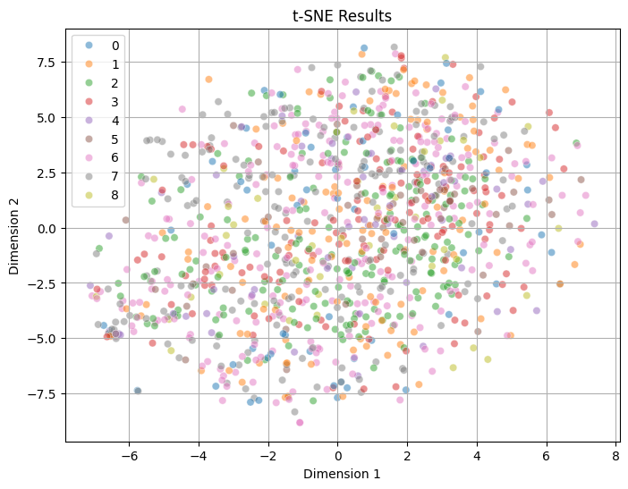

### Explaining Predictions using LIME

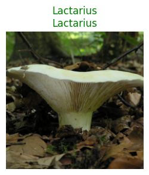

```
Agaricus: 0.015407
Amanita: 0.011837
Boletus: 0.015689
Cortinarius: 0.020258
Entoloma: 0.010260
Hygrocybe: 0.012788
Lactarius: 0.886726
Russula: 0.013066
Suillus: 0.013970
```

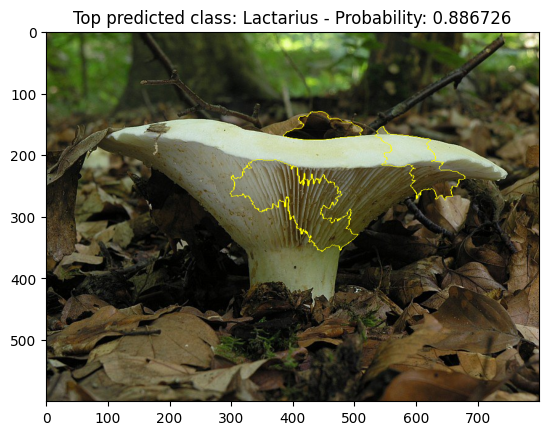

#### Future Improvements: